# Multi-City Comparison of Environmental Justice

Ryan Thomas

April 27, 2017

This analysis is inspired by the US EPA’s 2013 publication, [Ranking Distributions of Environmental Outcomes](https://www.epa.gov/sites/production/files/2014-12/documents/ranking_distributions_of_environmental_outcomes.pdf). The main point of this article is to determine how to rank distributions, rather than ranking absolute values. The ultimate form of this analysis should be to rank cities based on the distribution of each indicators included in the index.

```r
library(dplyr)
```

```r
library(tidyr)
library(ggplot2)
library(ineq)
library(data.table)
# set directory
#setwd("~/projects/urban_epi/data/stats/air/")

# TODO: Once we have all clean CSVs we can do
# list.files()
temp <- c("~/projects/urban_epi/data/stats/final/saopaulo.txt",
          "~/projects/urban_epi/data/stats/final/london.txt",
          "~/projects/urban_epi/data/stats/final/tokyo.txt",
          "~/projects/urban_epi/data/stats/final/beijing.txt")
# load files
cities <- lapply(temp, fread)
# take only unique rows
cities <- lapply(cities, unique)
#cities <- lapply(cities, '[', j=c(1:13))
# add city names
city <- strsplit(basename(temp), ".txt")
cities <- mapply(cbind, cities, "city"=city, SIMPLIFY=F)# take only cities with population and income
# cities <- cities[c(1,3,7,8)]# creates dataframe from list
# note currently broken as columns have separate names
pm <- do.call(rbind, lapply(cities, data.frame, stringsAsFactors=FALSE))#area.cities <- do.call(rbind, lapply(cities, "[", c("city","area")))#pop.cities <- do.call(rbind, lapply(cities[c(1,3,7,8)], "[", c("city","area", "Population")))# normalize income
normalize <- function(x){(x-min(x))/(max(x)-min(x))}
pm <- pm %>%
    group_by(city) %>%
    mutate(Income.std = normalize(Income)) %>%
    ungroup() %>%
    as.data.frame()
```

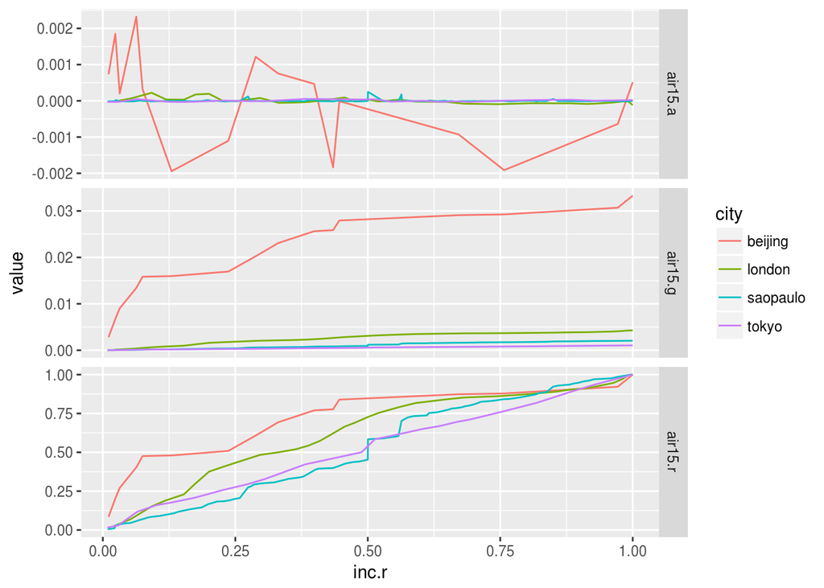

```r
l <- read.table("~/projects/urban_epi/data/vector/air/london.txt", sep="|", header = T, stringsAsFactors = F)

 pm %>% group_by(city) %>%
  mutate(tot.inc=(as.numeric(Income)*as.numeric(Population)),
         p.r=cumsum(Population)/sum(Population),
         inc.r=cumsum(tot.inc)/sum(tot.inc),

         # Since these are esxported from GRASS as average, we need to
         # multiply by the area to get the "total amount" of PM in the
         # neighborhood.
         air15.t=as.numeric(area)*as.numeric(a_average),

         # Cumulative exposure
         air15.c=cumsum(air15.t),
         air15.r=air15.c/sum(air15.t),      # Relative cumulative exposure
         air15.g=cumsum(air15.t/sum(Population)),     # Generalized cumulative exposure
         # Absolute cumulative exposure
         air15.a=air15.t/sum(Population)-mean(air15.t)/sum(Population)
         )  %>%
  arrange(p.r) %>%
    ungroup() %>%  as.data.frame() %>%

  select(city, nbhd, p.r, inc.r, starts_with("air15")) %>%
  #arrange(inc.r) %>%
  gather(indicator,value, c(air15.r, air15.g, air15.a)) %>%
  ggplot(aes(x=inc.r, y=value)) +
  geom_line(aes(colour=city)) +
  #geom_abline(slope=1, intercept = 0) +
  #xlab("Cumulative Percent of Poplation") +
  #ylab("Total Amount of Exposure Accounted For") +
  facet_grid(indicator ~ ., scales="free_y")
```

Here we are plotting each variable against the percentage of population. For income, the y axis would be the percentage of the total income accounted for by the corresponding percentage of population. For air15.r (average PM2.5 level in 2015), this is the percentage of the total exposure experienced by the corresponding percentage of the population. In the chart below, the x-axis represents the percentage of the total income earned (mean neighborhood income * neighborhood population).

TODO: Make the generalized curve where the x-axis is the accumulation per capita; Make the Absolute curve where the x-axis is the deviation from the mean.

```r
Atkinson(l$air15.r)
```

```
## [1] NaN
```